# Homework-2019.09.20

By 19056

2019/9/29

# Homework 1

## Question

```r
library(SC19056)
data("exams")
x<-exams
x$stu_id<-1:dim(x)[[1]]
p<-xtable::xtable((x))
print(p,type="html")
```

|  | exam1 | exam2 | gender | stu_id |
| --- | --- | --- | --- | --- |
| 1 | 2.70 | 2.80 | M | 1 |
| 2 | 3.30 | 2.00 | F | 2 |
| 3 | 4.00 | 4.00 | F | 3 |
| 4 | 2.30 | 1.80 | M | 4 |
| 5 | 2.20 | 1.50 | F | 5 |
| 6 | 3.30 | 3.70 | M | 6 |
| 7 | 3.00 | 2.40 | M | 7 |
| 8 | 3.40 | 3.50 | F | 8 |
| 9 | 3.20 | 2.20 | F | 9 |
| 10 | 2.40 | 2.60 | M | 10 |
| 11 | 4.10 | 2.70 | F | 11 |
| 12 | 3.60 | 3.80 | M | 12 |
| 13 | 2.60 | 2.20 | F | 13 |
| 14 | 3.70 | 3.00 | F | 14 |
| 15 | 3.50 | 3.10 | M | 15 |

## Answer

To dicuss the impact of gender on performance. Firstly,we get the exams scrore of male and female students.

```r
exam_m<-(subset(x,x$gender=="M")[-3])
exam_f<-(subset(x,x$gender=="F")[-3])
```

Male students :

```r
p<-xtable::xtable((exam_m))
print(p,type="html")
```

|  | exam1 | exam2 | stu_id |
| --- | --- | --- | --- |
| 1 | 2.70 | 2.80 | 1 |
| 4 | 2.30 | 1.80 | 4 |
| 6 | 3.30 | 3.70 | 6 |
| 7 | 3.00 | 2.40 | 7 |
| 10 | 2.40 | 2.60 | 10 |
| 12 | 3.60 | 3.80 | 12 |
| 15 | 3.50 | 3.10 | 15 |

Femake student:

```r
p<-xtable::xtable((exam_f))
print(p,type="html")
```

|  | exam1 | exam2 | stu_id |
| --- | --- | --- | --- |
| 2 | 3.30 | 2.00 | 2 |
| 3 | 4.00 | 4.00 | 3 |
| 5 | 2.20 | 1.50 | 5 |
| 8 | 3.40 | 3.50 | 8 |
| 9 | 3.20 | 2.20 | 9 |
| 11 | 4.10 | 2.70 | 11 |
| 13 | 2.60 | 2.20 | 13 |
| 14 | 3.70 | 3.00 | 14 |

Then we draw a scatter plot of boy and girl students in which red point are boy students and blue point are girl students.

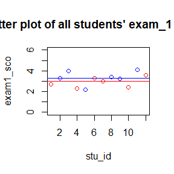

```r
a_exam1_m<-mean(exam_m[,1])
a_exam1_f<-mean(exam_f[,1])
plot(exam_m[,3],exam_m[,1],main="Scatter plot of all students' exam_1 scrore?",xlim=c(1,12),ylim=c(0,6),xla="stu_id",yla="exam1_sco",col="red")
points(exam_f[,3],exam_f[,1],col="blue")
abline(h=a_exam1_m, col="red")
abline(h=a_exam1_f, col="blue")
```

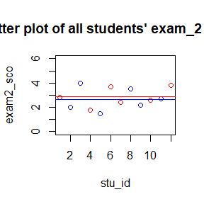

```r
a_exam2_m<-mean(exam_m[,2])
a_exam2_f<-mean(exam_f[,2])
plot(exam_m[,3],exam_m[,2],main="Scatter plot of all students' exam_2 scrore?",xlim=c(1,12),ylim=c(0,6),xla="stu_id",yla="exam2_sco",col="red")
points(exam_f[,3],exam_f[,2],col="blue")
abline(h=a_exam2_m, col="red")
abline(h=a_exam2_f, col="blue")
```

From the above scatter plot, we know that for exam1, female students perform better than male students and for exam2, male students perform better than female students

To dicuss the correlation between the two exams.We do a regression analysis of the two exams.Firstly,we drowa scatter plot of exam1 and exam2.

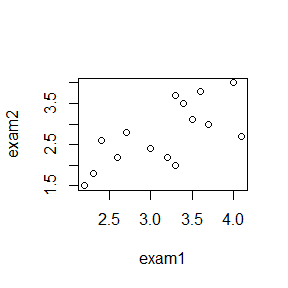

```r
plot(x$exam1,x$exam2,xla="exam1",yla="exam2")
```

Then we do a regression analysis of the two exams:

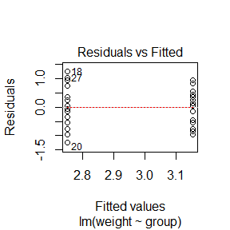

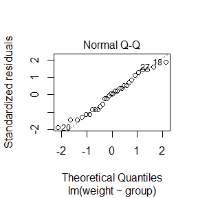

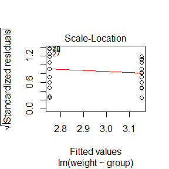

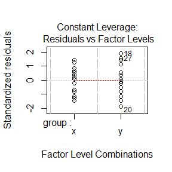

```r
weight<-c(x$exam1,x$exam2)
group<-gl(2,dim(x)[[1]],2*dim(x)[[1]],labels=c("x","y"))
lm_ex<-lm(weight~group)
#par(mfrow=c(2,2))
plot(lm_ex)
```

```r
summary(lm_ex)$coef
```

```
##              Estimate Std. Error   t value     Pr(>|t|)
## (Intercept)  3.153333  0.1771109 17.804292 8.365005e-17
## groupy      -0.400000  0.2504726 -1.596981 1.214958e-01
```

```r
y<-summary(lm_ex)$coef
```

# Homework 2

## 3.4:

Develop an algorithm to generate random samples from a Rayleigh($\sigma$) distribution.Generate Rayleigh($\sigma$) samples for several choices of $\sigma>0$ and check that the mode of the generated samples is close to the theoretical mode $\sigma$ (check the histogram).

## 3.11:

Generate a random sample of size 1000 from a normal location mixture. The components of the mixture have $N(0, 1)$ and $N(3, 1)$ distributions with mixing probabilities $p_{1}$ and $p_{2}=1-p_{1}$. Graph the histogram of the sample with density superimposed, for $p_{1} = 0.75$. Repeat with different values for $p_{1}$ and observe whether the empirical distribution of the mixture appears to be bimodal. Make a conjecture about the values of p1 that produce bimodal mixtures.

## 3.18:

Write a function to generate a random sample from a $W_{d}(\sum,n)$ (Wishart) distribution for$n>d+1>=1$, based on Bartlett’s decomposition.

## Answer

## 3.4:

### Inverse transformation method:

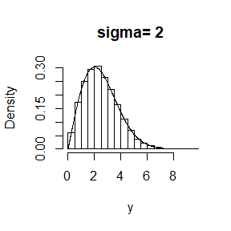

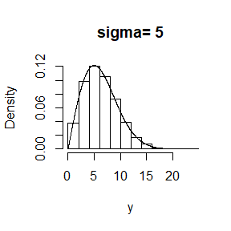

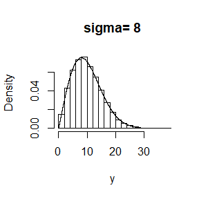

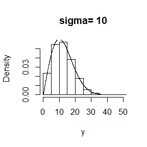

```r
# Define a function to drow histogram for any sigma.
plot_sigma1<-function(sigma){
  f_x<-function(x){
    return((x/sigma^2)*exp(-(x^2)/(2*sigma^2)))
    }
set.seed(12345)
n<-10000
u<-runif(n)
y<-sigma*sqrt(-2*log(1-u))
hist(y,prob=TRUE,main =paste("sigma=",sigma))
x<-seq(0,60,.01)
lines(x,f_x(x))
}
#par(mfrow=c(2,2))
plot_sigma1(2);plot_sigma1(5);plot_sigma1(8);plot_sigma1(10)
```

### Acceptance-rejection method:

We choose up distributon as $\Gamma(2,\frac{1}{2\sigma^2})$,then

Let $c=4\sigma^2/e^{\frac{-1}{2\sigma^2}}$,then $f(x)\leqslant cg(x)$

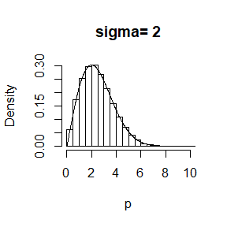

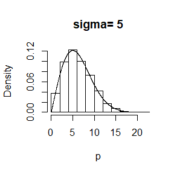

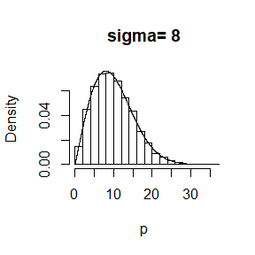

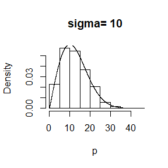

```r
# Define a function to drow histogram for any sigma.
plot_sigma2<-function(sigma){
 f_x<-function(x){
    return((x/sigma^2)*exp(-(x^2)/(2*sigma^2)))
    }
  n<-1e6
  c<-4*sigma^2/(exp(-1/(2*sigma^2)))
  y<-rgamma(n,2,1/(2*sigma^2))
  u<-runif(n)
  p<-y[which(f_x(y)/(c*dgamma(y,2,1/(2*sigma^2)))>=u)]
  hist(p,prob=TRUE,main =paste("sigma=",sigma))
  x<-seq(0,60,.01)
  lines(x,f_x(x))
 # lines(x,c*dgamma(x,2,1/(2*sigma^2)))
}
#par(mfrow=c(2,2))
plot_sigma2(2);plot_sigma2(5);plot_sigma2(8);plot_sigma2(10)
```

### Transformation methods:

Because $f(x)=\frac{x}{\sigma^2 }e^{\frac{-x^2}{2\sigma^2}}$,then $Y=X^2 \sim E(\frac{1}{2\sigma^2})$

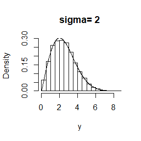

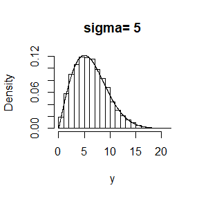

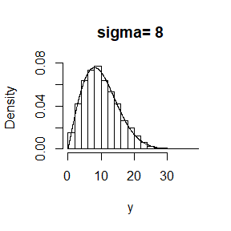

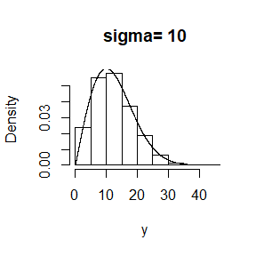

```r
# Define a function to drow histogram for any sigma.
plot_sigma3<-function(sigma){
  f_x<-function(x){
    return((x/sigma^2)*exp(-x^2/(2*sigma^2)))
    }
  n<-1e4
  y<-sqrt(rexp(n,1/(2*sigma^2)))
  hist(y,prob=TRUE,main =paste("sigma=",sigma))
  x<-seq(0,60,.01)
  lines(x,f_x(x))
}
#par(mfrow=c(2,2))
plot_sigma3(2);plot_sigma3(5);plot_sigma3(8);plot_sigma3(10)
```

## 3.11:

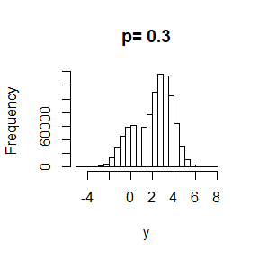

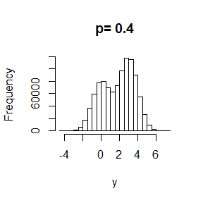

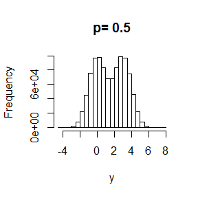

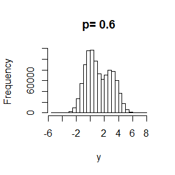

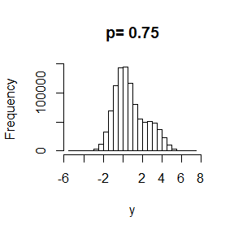

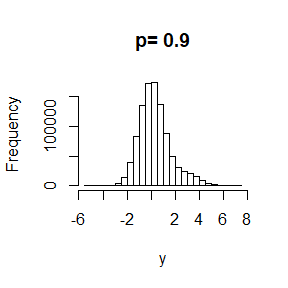

```r
n<-1e6
# Define a function to drow histogram for any p1
get_norm<-function(p){
x<-sample(0:1,n,replace = TRUE,c(1-p,p))
y<-vector(length=length(x))
  for(i in 1:length(x)){
    if (x[i]==1)
    y[i]<-rnorm(1)
    else
      y[i]<-rnorm(1)+3
  }
  hist(y,main=paste("p=",p))
}
#par(mfrow=c(2,3))
get_norm(.3);get_norm(.4);get_norm(.5);get_norm(.6);get_norm(.75);get_norm(.9)
```

## 3.18:

```r
library(MASS)
n<-20
p<-6
# Get Covariance matrix sigma:
w<-matrix(sample(-10:10,p*p,replace = TRUE),p,p)
sigma<-cov(w)
# Produce random variable based on  Multivariate normal distribution.
x<-mvrnorm(n, sample(-3:3,p,replace = TRUE), sigma)
s<-matrix(0,p,p)
for (i in 1:n){
  s<-s+(as.matrix(x[i,])%*%t(as.matrix(x[i,])))
}
s
```

```
##           [,1]      [,2]       [,3]       [,4]      [,5]      [,6]
## [1,]  629.3675 -542.9869  277.06944  166.26947  342.6024 -848.2889
## [2,] -542.9869 1029.6833 -445.34915 -145.02364 -420.0324  966.9149
## [3,]  277.0694 -445.3492  616.14653   88.51815  191.7813 -355.1683
## [4,]  166.2695 -145.0236   88.51815  210.93233  274.6320 -239.3815
## [5,]  342.6024 -420.0324  191.78128  274.63200  634.0250 -718.6142
## [6,] -848.2889  966.9149 -355.16828 -239.38146 -718.6142 1446.0923
```

# Homework 3

## 5.15

Obtain the stratified importance sampling estimate in Example 5.13 and compare it with the result of Example 5.10.

## Answer

## 5.1

### Simple MC

```r
set.seed(123)
n<-1e7
x<-(pi/3)*runif(n)
y<-sin(x)*(pi/3)
I<-mean(y)
m<-matrix(c(mean(y),var(y)),1,2)
rownames(m)<-"Simple MC  "
colnames(m)<-c("mean","variance")
p<-knitr::kable(m)
print(p,type="latex")
```

|  | mean | variance |
| --- | --- | --- |
| Simple MC | 0.4999548 | 0.0715782 |

### Antithetic variables

```r
n<-1e7
x1<-(pi/3)*runif(n)
x2<-pi/3-x1
y1<-sin(x1)*(pi/3)
y2<-sin(x2)*(pi/3)
I<-mean(y1+y2)/2
m<-matrix(c(I,var((y1+y2)/2)),1,2)
rownames(m)<-"Control variate  "
colnames(m)<-c("mean","variance")
p<-knitr::kable(m)
print(p,type="latex")
```

|  | mean | variance |
| --- | --- | --- |
| Control variate | 0.5000049 | 0.0004402 |

### Control variate

```r
n<-1e7
x<-(pi/3)*runif(n)
y<-sin(x)*(pi/3)
a<--cov(x,y)/var(x)
y<-sin(x)*(pi/3)+a*(x-pi/6)
m<-matrix(c(mean(y),var(y)),1,2)
rownames(m)<-"Control variate  "
colnames(m)<-c("mean","variance")
p<-knitr::kable(m)
print(p,type="latex")
```

|  | mean | variance |
| --- | --- | --- |
| Control variate | 0.4999847 | 0.0004512 |

## 5.10

### Simple MC

```r
n<-1e7
x1<-runif(n)
y1<-exp(-x1)/(1+x1^2)
I<-mean(y1)
m<-matrix(c(I,var(y1)),1,2)
rownames(m)<-"Simple MC  "
colnames(m)<-c("mean","variance")
p<-knitr::kable(m)
print(p,type="latex")
```

|  | mean | variance |
| --- | --- | --- |
| Simple MC | 0.5247283 | 0.0600203 |

### Antithetic variables

```r
library(scales)
n<-1e7
x1<-runif(n/2)
x2<-1-x1
y1<-exp(-x1)/(1+x1^2)
y2<-exp(-x2)/(1+x2^2)
I<-mean(y1+y2)/2
m<-matrix(c(I,var((y1+y2)/2)),1,2)
rownames(m)<- "Antithetic variables"
colnames(m)<-c("mean","variance")
p<-knitr::kable(m)
print(p,type="latex")
```

|  | mean | variance |
| --- | --- | --- |
| Antithetic variables | 0.5248056 | 0.0010955 |

We konw that the approximate reduction in variance is 98%

## 5.15

### Importance sampling and stratified Importance sampling

```r
n<-1e5
K<-5
N<-1000
Y<-numeric(K)
est <-matrix(0, N, 2)
F<-function(k,K)
  {
    return(c((1-exp(-(k-1)/5))/(1-exp(-1)),(1-exp(-k/K))/(1-exp(-1))))
}
for(j in 1:N){
  x<--log(1-(1-exp(-1))*runif(n))
  y<-(1-exp(-1))/(1+x^2)
for (i in 1:K){
  u<-runif(n*(F(i,K)[2]-F(i,K)[1]))
  u1<-u*(F(i,K)[2]-F(i,K)[1])+F(i,K)[1]
  x1<--log(1-(1-exp(-1))*u1)
  y1<-(F(i,K)[2]-F(i,K)[1])*(1-exp(-1))/(1+x1^2)
  Y[i]<-mean(y1)
}
  est[j,1]<-mean(y)
  est[j,2]<-sum(Y)
}
```

We know:

```r
m<-matrix(nrow=2,ncol=2)
m[1,]<-apply(est,2,mean)
m[2,]<-apply(est,2,sd)
colnames(m)<-c("Importance sampling","Stratified importance sampling")
rownames(m)<-c("mean","standard error")
p<-knitr::kable(m)
print(p,type="latex")
```

|  | Importance sampling | Stratified importance sampling |
| --- | --- | --- |
| mean | 0.5248019 | 0.5247968 |
| standard error | 0.0003029 | 0.0000558 |

## Exercise 5.13

### Importance sampling

```r
set.seed(1234)
n<-1e6
u<-runif(n)
x1<-sqrt(-2*log((1-u)/exp(1/2)))
x2<-(-3*log((1-u)/exp(1/3)))^(1/3)
y1<-x1/(2*pi*exp(1))^(1/2)
y2<-1/((2*pi)^(1/2)*exp(1/3))*exp(x2^3/3-x2^2/2)
I1<-mean(y1)
I2<-mean(y2)
I1
```

```
## [1] 0.4006345
```

```r
I2
```

```
## [1] 0.4012781
```

```r
var(y1)
```

```
## [1] 0.01520037
```

```r
var(y2)
```

```
## [1] 3.756147
```

## Stratified sampling

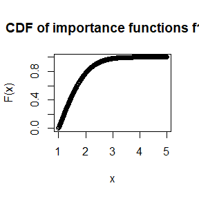

```r
l<-seq(1,5,0.01)
plot(l,1-exp(1/2-l^2/2),xlab="x",ylab="F(x)",main = paste("CDF of importance functions f1(x)"))
```

From the CDF above ,we find $F(x)$ is alomst $1$ wen $x=3$ .SO,we choose $K=3$,and divide interval $[1,\infty]$ into three pieces $[1,2],[2,3]$ and $[3,\infty]$.

```r
n<-1e6
K<-3
N<-50
Y<-numeric(K)
est <-matrix(0, N, 2)
F<-function(k)
  {
    if(k<=2)
    return(c(1-exp(1/2-k^2/2),1-exp(1/2-(k+1)^2/2)))
     else
    return(c(1-exp(1/2-k^2/2),0.9999))
}
for(j in 1:N){
  x<-sqrt(-2*log((1-runif(n))/exp(1/2)))
  y<-x/(2*pi*exp(1))^(1/2)
for (i in 1:K){
  u<-runif(n*(F(i)[2]-F(i)[1]))
  u1<-u*(F(i)[2]-F(i)[1])+F(i)[1]
  x1<-sqrt(-2*log((1-u1)/exp(1/2)))
  y1<-(F(i)[2]-F(i)[1])*x1/(2*pi*exp(1))^(1/2)
  Y[i]<-mean(y1)
}
  est[j,1]<-mean(y)
  est[j,2]<-sum(Y)
}
apply(est,2,mean)
```

```
## [1] 0.4006144 0.4005044
```

```r
apply(est,2,sd)
```

```
## [1] 1.249745e-04 6.958212e-05
```

# Homework 4

## 6.5

Suppose a $95\%$ symmetric t-interval is applied to estimate a mean, but the sample data are non-normal. Then the probability that the confidence interval covers the mean is not necessarily equal to $0.95$.Use a Monte Carlo experiment to estimate the coverage probability of the t-interval for random samples of $\chi^2(2)$ data with sample size $n = 20$.Compare your t-interval results with the simulation results in Example $6.4$ .(The t-interval should be more robust to departures from normality than the interval for variance.)

Estimate the $0.025$, $0.05$, $0.95$, and $0.975$ quantiles of the skewness $\sqrt b_1$ under normality by a Monte Carlo experiment. Compute the standard error of the estimates from $(2.14)$ using the normal approximation for the density (with exact variance formula). Compare the estimated quantiles with the quantiles of the large sample approximation $\sqrt b_1 \approx N(0,6/n)$

## Anser

## 6.5

### Confidence interval with $\frac{\alpha}{2}$ up-bound and $\frac{\alpha}{2}$ low-bound.

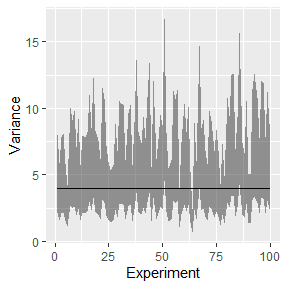

```r
library(ggplot2)
set.seed(123)
M<-100
n <- 20
alpha <- .05
U<-U1<-matrix(ncol=2)
for (i in 1:M){
x <- rnorm(n, mean=0, sd=2)
U<-rbind(U,c((n-1) * var(x) / qchisq(alpha/2, df=n-1),(n-1) * var(x) / qchisq(1-alpha/2, df=n-1)))
}
U<-U[-1,]
c<-sum(((U[,1]-4)*(U[,2]-4))<0)/100
O<-as.data.frame(cbind(1:M,U))
O<-as.data.frame(cbind(4,O))
colnames(O)<-c("Variance","Experiment","upper_bound","down_bound")
par(mfrow=c(2,1))
ggplot(O, aes(x = Experiment,y=Variance )) +
geom_ribbon(aes(ymin =O[,4], ymax=O[,3]),alpha=0.5)+
geom_line()
```

The frequency that the confidence interval covers the variance is equal to 96%.

### Confidence interval with $\alpha$ up-bound

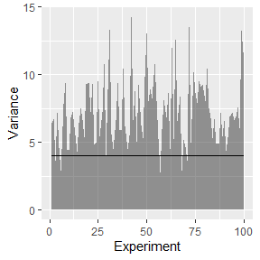

```r
for (i in 1:M){
  x <- rnorm(n, mean=0, sd=2)
  U1<-rbind(U1,c((n-1) * var(x) / qchisq(alpha, df=n-1),(n-1) * var(x) / qchisq(1-alpha, df=n-1)))
  }
U1<-U1[-1,]
c<-sum((U1[,1]-4)>0)/100
O1<-as.data.frame(cbind(1:M,U1))
O1<-as.data.frame(cbind(4,O1))
colnames(O1)<-c("Variance","Experiment","Confidence upper bound","Confidence down bound")
ggplot(O1, aes(x = Experiment,y=Variance )) +
geom_ribbon(aes(ymin =0, ymax=U1[,1]),alpha=0.5)+
geom_line()
```

The frequency that the confidence interval covers the variance is equal to 94%.

### Estimation with symmetric t-interval

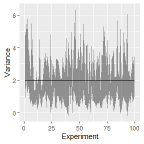

```r
library(ggplot2)
M<-100
n <- 10
alpha <- .05
U<-U1<-matrix(ncol=2)
for (i in 1:M){
  x<-rchisq(n,df=2)
  U<-rbind(U,c(mean(x)+qt(1-alpha/2,df=n-1)*sqrt(var(x)/n),mean(x)-qt(1-alpha/2,df=n-1)*sqrt(var(x)/n)))
  }
U<-U[-1,]
c<-sum(((U[,1]-2)*(U[,2]-2))<0)/100
O<-as.data.frame(cbind(1:M,U))
O<-as.data.frame(cbind(2,O))
colnames(O)<-c("Variance","Experiment","upper_bound","down_bound")
ggplot(O, aes(x = Experiment,y=Variance )) +
geom_ribbon(aes(ymin =O[,4], ymax=O[,3]),alpha=0.5)+
geom_line()
```

## 6.6

```r
estimate_q<-function(n){
M<-1000
P<-numeric(M)
for (i in 1:M){
x<-rnorm(n)
b1<-mean(x^3)
P[i]<-b1
}
q<-c(0.025,0.05,0.95,0.975)
sd<-numeric(4)
f_q<-function(q) {
  x<-qnorm(q,0,sd=sqrt(6*(n-2)/((n+1)*(n+3))))
return(dnorm(x,0,sqrt(6*(n-2)/((n+1)*(n+3)))))
}
sd<-sqrt(q*(1-q)/(n*f_q(q)^2))
P<-quantile(P,q)
P1<-qnorm(q,0,sqrt(6/n))
names(P)<-NULL
e<-matrix(0,4,3)
e[,1]<-P
e[,2]<-P1
e[,3]<-sd
return(e)
}
```

### We choose $n=10,20,100,1000,10000$

```r
N<-c(10,20,100,1000,10000)
for (i in N){
m<-estimate_q(i)
rownames(m)<-c("2.5%","5%","95%","97.5%")
colnames(m)<-c("Mc estimation","normal estimation","Standard error")
p<-knitr::kable(m)
print(p,type="latex")
}
```

|  | Mc estimation | normal estimation | Standard error |
| --- | --- | --- | --- |
| 2.5% | -2.642711 | -1.518182 | 0.4894147 |
| 5% | -2.167775 | -1.274098 | 0.3871601 |
| 95% | 1.793000 | 1.274098 | 0.3871601 |
| 97.5% | 2.272216 | 1.518182 | 0.4894147 |

|  | Mc estimation | normal estimation | Standard error |
| --- | --- | --- | --- |
| 2.5% | -1.683669 | -1.0735165 | 0.2824540 |
| 5% | -1.248427 | -0.9009234 | 0.2234402 |
| 95% | 1.518641 | 0.9009234 | 0.2234402 |
| 97.5% | 1.803280 | 1.0735165 | 0.2824540 |

|  | Mc estimation | normal estimation | Standard error |
| --- | --- | --- | --- |
| 2.5% | -0.7839992 | -0.4800912 | 0.0635088 |
| 5% | -0.6355142 | -0.4029052 | 0.0502397 |
| 95% | 0.6280262 | 0.4029052 | 0.0502397 |
| 97.5% | 0.7814226 | 0.4800912 | 0.0635088 |

|  | Mc estimation | normal estimation | Standard error |
| --- | --- | --- | --- |
| 2.5% | -0.2342286 | -0.1518182 | 0.0065238 |
| 5% | -0.2054866 | -0.1274098 | 0.0051607 |
| 95% | 0.2042721 | 0.1274098 | 0.0051607 |
| 97.5% | 0.2532013 | 0.1518182 | 0.0065238 |

|  | Mc estimation | normal estimation | Standard error |
| --- | --- | --- | --- |
| 2.5% | -0.0759378 | -0.0480091 | 0.0006541 |
| 5% | -0.0645105 | -0.0402905 | 0.0005175 |
| 95% | 0.0643451 | 0.0402905 | 0.0005175 |
| 97.5% | 0.0768066 | 0.0480091 | 0.0006541 |

# Homework 5

## Exercises 6.7:

Estimate the power of the skewness test of normality against symmetric $Beta(\alpha,\alpha)$ distributions and comment on the results. Are the results different for heavy-tailed symmetric alternatives such as $t (v)$ ?

## Exercises 6.A:

Use Monte Carlo simulation to investigate whether the empirical Type I error rate of the t-test is approximately equal to the nominal significance level $\alpha$, when the sampled population is non-normal. The t-test is robust to mild departures from normality. Discuss the simulation results for the cases where the sampled population is (i) $\chi^2(1)$, (ii) Uniform(0,2), (iii) Exponential( rate=1). In each case, test $H_{0}:\mu=\mu_{0}$ vs $H_{1}:\mu \neq\mu_{0}$, where $\mu_0$ is the mean of $\chi^2(1)$, Uniform(0,2), and Exponential(1), respectively.

## Answer:

## Exercises 6.7

```r
set.seed(1)
f<-function(pdf,epsilon,I){
n<-100
cv <- qnorm(.975, 0, sqrt(6/n))
M<-1e3
p<-numeric(M)
power<-numeric(length(epsilon))
for (j in 1:length(epsilon)){
for (i in 1:M){
J<-sample(1:2,n,replace = TRUE,prob=c(1-epsilon[j],epsilon[j]))
if (pdf==1){
x<-rbeta(n,1,1)*(J==1)+rbeta(n,10,10)*(J==2)*I(I==0)+rbeta(n,1,100)*(J==2)*I(I==1)
}
if (pdf ==2){
x<-rt(n,5)*(J==1)+rbeta(n,5,5)*(J==2)
}
xbar <- mean(x)
m3 <- mean((x - xbar)^3)
m2 <- mean((x - xbar)^2)
t<-abs(m3/(m2^1.5))
p[i]<-(t>cv)
}
  power[j]<-sum(p)/M
}
return(power)
}
epsilon<-seq(0,1,length.out = 30)
```

$\cdot$We use kewness test of normality against mixture distribution based on $beta(1,1) $ contaminated by symmetric $beta(10,10)$ and unsymmetric $beta(1,100)$.

[figure not shown]

```r
par(mfrow=c(1,2))
plot(epsilon,f(1,epsilon,0),type="l",ylab="power",main="contaminated by beta(10,10) ")
plot(epsilon,f(1,epsilon,1),type="l",ylab="power",main="contaminated by beta(1,100) ")
```

In the picture 1,we find that kewness test of normality is Conservative and power is almost zero when $\epsilon$ is less than $0.6$ .This is because the kewness of mixture distribution is zero.In the picture 2,kewness test of normality is good at giving true result and power is almost 1 when $\epsilon$ get $0.5$.

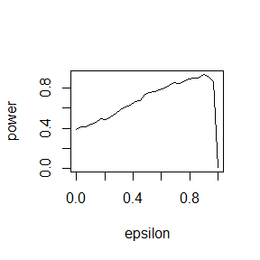

```r
plot(epsilon,f(2,epsilon),type="l",ylab="power")
```

## Exercises 6.A

```r
M<-1e4
n<-20
mu<-1
#p<-numeric(3)
result<-matrix(0,M,4)
cv<-qt(.975,n-1)
for (i in 1:M){
x1<-rchisq(n,1)
x2<-runif(n,0,2)
x3<-rexp(n,1)
x4<-rnorm(n,1,1)
result[i,1]<-abs(mean(x1-mu)/sqrt(var(x1)/n))>cv
result[i,2]<-abs(mean(x2-mu)/sqrt(var(x2)/n))>cv
result[i,3]<-abs(mean(x3-mu)/sqrt(var(x3)/n))>cv
result[i,4]<-abs(mean(x4-mu)/sqrt(var(x4)/n))>cv
}
p<-t(as.matrix(apply(result,2,mean)))
rownames(p)<-"empirical Type I error"
colnames(p)<-c("chi","uniform","Exponential","normal")
m<-knitr::kable(p)
print(m,type="latex")
```

|  | chi | uniform | Exponential | normal |
| --- | --- | --- | --- | --- |
| empirical Type I error | 0.1019 | 0.0493 | 0.0796 | 0.0483 |